# Final Project

Hui-Chen Betty Liu

December 6, 2019

### Problem Statement

> Is there a significant difference in income between men and women? Does the difference vary depending on other factors (e.g., education, marital status, criminal history, drug use, childhood household factors, profession, etc.)?

### **(0)** Data cleaning and data exploration

The original nlsy dataset used for this project has 12686 observations and 67 variables. The cleaned data set has 7024 obversations and 68 variables. This data cleaning process involved recoding all variables, adding new variables as well as those that are not meaningful in this context.

First, the observations that have missing values in the outcome variable (2012 income) are filtered out because the analyses require we have non-null values for the outcome variable. This reduced the number of observations to 7024.

All variables were renamed so that they are descriptive. For example, the variable representing gender was originally `R0214800` and is renamed `gender`.

Many of the variables have negative values recorded, which represent different non-responses. For exmple, -5 represents “Non-interview”. Rather than including these values as a negative numeric values, these non-responses were recoded as NA. Most variables have just negative numbers recoded as NA, while some have additional values coded as NA because I have decided they can be treated as NA in this context. An example is “not currently in the workforce” for the question about occupation. Sometimes, non-response are recoded because they are meaningful. An example is the use of cocaine. A respondent who refuses to report their drug use or says “I don’t know” is different from the non-reponses representing respondents who were not given the question.

Numerical variables that have values representing qualitative responses were recoded as categorical variables. The values were reordered in a way that makes sense in this context. For example, for levels of education, the values are re-ordered from lowest to highest level of education. For a few variables, such as education and religion, new variables were created that have binned values such as “completed high school” and “Christian” (collapsing different Christian denominations). Two of the family values survey questions were recoded to reflect a general “misogynist scale”. The higher the ratings, the more likely that the respondent is misogynist and reflects attitudes that widen the difference betwen men and women.

Very few (only 5) variables were dropped. These variables, such as `version`, were dropped from the cleaned dataset because they are not meaningful in this context and are not used in the analysis to answer the research question. The reason for dropping each variable is included below:

- `version` was dropped because it’s the same (445) for every respondent.
- `age14.south` was dropped because the interpretation is unclear. It’s unclear if “Yes” means reside in the south at age 14 or not.
- `income2012x` was dropped because the information is already captured by `income2012` and because it only has 64 observations.
- `income2012y` was dropped because the information is already captured by `income2012` and because it only has 64 observations.
- `spouse.income2012r` was dropped because the information is already captured by `spouse.income2012` and because it only has 54 observations.

A couple new variables were created. `age.spouse` was created to capture information about the spouse’s age using values from `partner.birthyear`. The variable `income.topcoded` was created to label the top 2% income earners whose values in the outcome variable were recorded as $343,830, which is the average income of the top 2% income earners in the data set. This variable is then used to create a filtered data set that most of the analyses are based on. Throughout the analyses, I will check to see if the inclusion of the topcoded values change the conclusions of the analyses. For reference, the data frames `nlsydata4` and `nlsydata3` are identical except for this difference. `nlsydata4` filters out the topcoded income earners (which contains 143 respondents, with a high proportion of men). `nlsydata3` contains the topcoded respondents.

### **(1)** Data Summary

After initial data exploration, I decided to categorize the variables into the following groups:

- Childhood Upbringing:
  - `us.born`
  - `usborn.south`
  - `multilingual`
  - `language`
  - `age14.urban`
  - `christian`
  - `religion`
  - `police.frisk`
  - `age.1stfrisk` (numeric)
- Geographical:
  - `us.region`
  - `urban.residence`
- Ethnicity and Social Status:
  - `race`
  - `poverty1979`
  - `poverty1990`
  - `poverty2000`
- Marriage and Family Planning:
  - `marital.status1979`
  - `familysize1979` (numeric)
  - `nonbio.children` (numeric)
  - `age.nonbiokid` (numeric)
  - `number.children` (numeric)
  - `familysize2000` (numeric)
  - `household.income1999` (numeric)
  - `maritalc.status2000`
  - `marital.status2000`
  - `months.marryto1stkid`
  - `familysize2012` (numeric)
- Spouse:
  - `spouse.occupation2000`
  - `spouse.workhours2000` (numeric)
  - `partner.birthyear`
  - `spouse.occupation2012`
  - `spouse.workhours2012` (numeric)
  - `spouse.income2012` (numeric)
  - `age.spouse` (numeric)
- Education:
  - `education1979`
  - `education1990`
  - `education2012`
  - `exp.edu1979`
  - `edu.completedin1990`
  - `edu.completedin2012`
- Work Experience, Ambitions, Income:
  - `veteran`
  - `ideal.occupation`
  - `schoolin5years`
  - `income1990` (numeric)
  - `jobsheld.1990` (numeric)
  - `industry2000`
  - `occupation2000`
  - `income2000` (numeric)
  - `industry2012`
  - `occupation2012`
  - `jobs.held2012` (numeric)
- Values:
  - `fa.womenathome`
  - `fa.notimetowork`
  - `fa.proworkwife`
  - `fa.badchildren`
  - `fa.genderrole`
  - `fa.menhousework`
  - `fa.happytradrole`
- Criminal History and Substance Use:
  - `crime.charge`
  - `age.1stalcohol` (numeric)
  - `marijuana`
  - `age.1stmarijuana` (numeric)
  - `cocaine1990`
  - `age.1stcocaine` (numeric)
  - `alcohol.dailyconsume` (numeric)

`gender`, `income2012`, and `income.topcoded` are not in any of the categories above.

The assumption is that the variables within each group are similar to each other and have high covariate because they are getting at the same information. That is, the variables in the Childhood Upbringing category might help describe the affect of the respondent’s childhood on his/her future income. Every variable is presented in a way to see if men and women are treated differently, and if that difference has an effect of their income. This helps us see if the income gap between men and women is correlated with a specific aspect of their life experiences.

In this section, I will compare the variables within each group to see which best explains the difference in income between men and women. In the next section, I will choose a subset of these variables for a linear regression analysis.

**(a)** Childhood Uprbringing

```
## # A tibble: 2 x 5
##   us.born income.gap  upper  lower is.significant
##   <fct>        <dbl>  <dbl>  <dbl>          <dbl>
## 1 US          13086. 11379. 14793.              1
## 2 Non-US      16410.  9729. 23092.              1
```

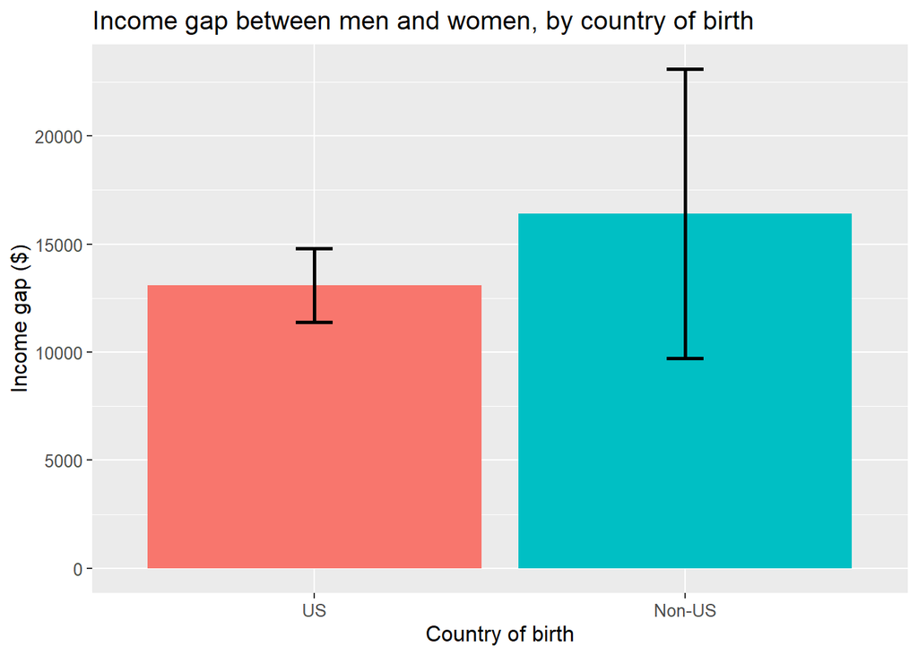

```
## # A tibble: 2 x 5
##   usborn.south income.gap  upper  lower is.significant
##   <fct>             <dbl>  <dbl>  <dbl>          <dbl>
## 1 Non-South        15912. 13583. 18240.              1
## 2 South             9113.  6640. 11585.              1
```

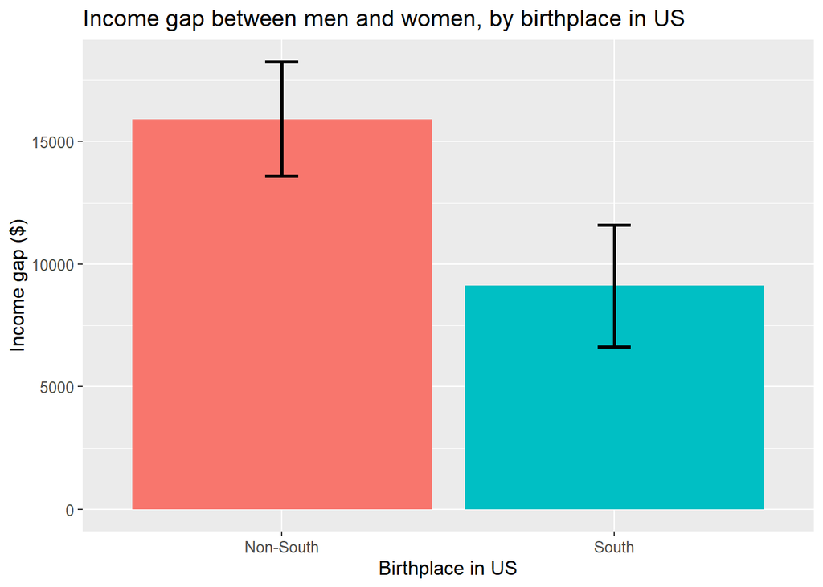

```
## # A tibble: 2 x 5
##   multilingual income.gap  upper  lower is.significant
##   <fct>             <dbl>  <dbl>  <dbl>          <dbl>
## 1 English          13965. 12052. 15878.              1
## 2 Multilingual     11287.  7999. 14575.              1
```

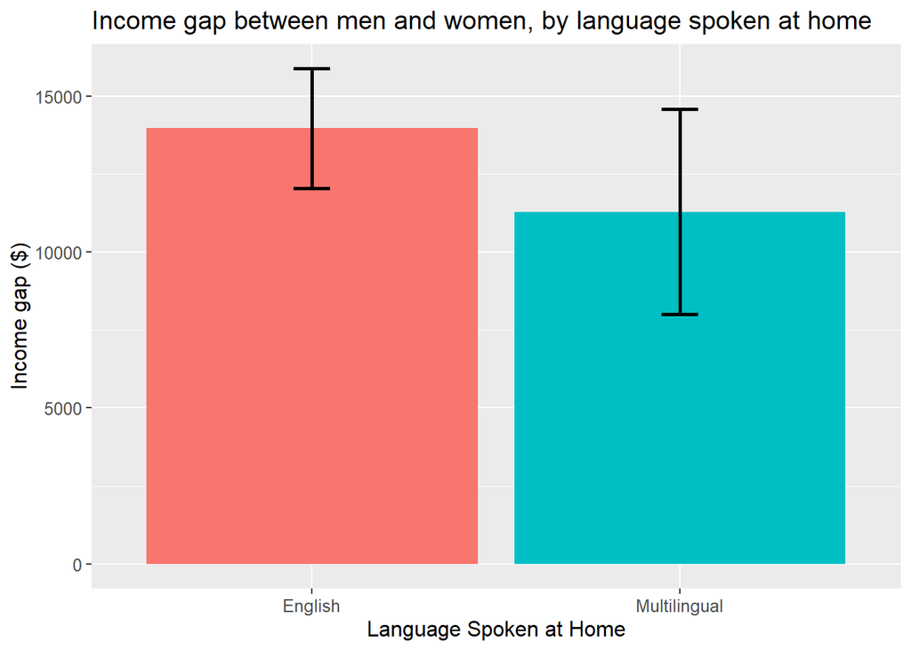

```
## # A tibble: 4 x 5
##   language income.gap   upper  lower is.significant
##   <fct>         <dbl>   <dbl>  <dbl>          <dbl>
## 1 Spanish      10178.   6557. 13798.              1
## 2 French        7036. -15523. 29596.              0
## 3 German       21763.   4369. 39157.              1
## 4 Other        17565.   7134. 27996.              1
```

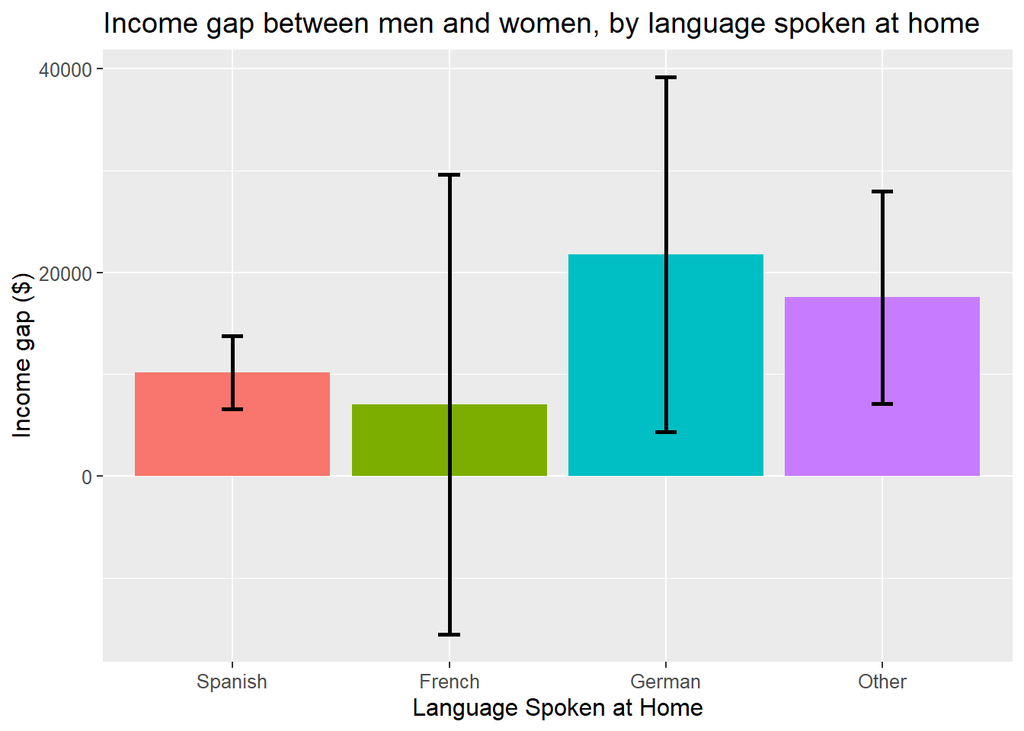

```
## # A tibble: 3 x 5
##   age14.urban income.gap  upper  lower is.significant
##   <fct>            <dbl>  <dbl>  <dbl>          <dbl>
## 1 City            13245. 11340. 15150.              1
## 2 Country         15127. 11300. 18955.              1
## 3 Farm            10599.  3800. 17397.              1
```

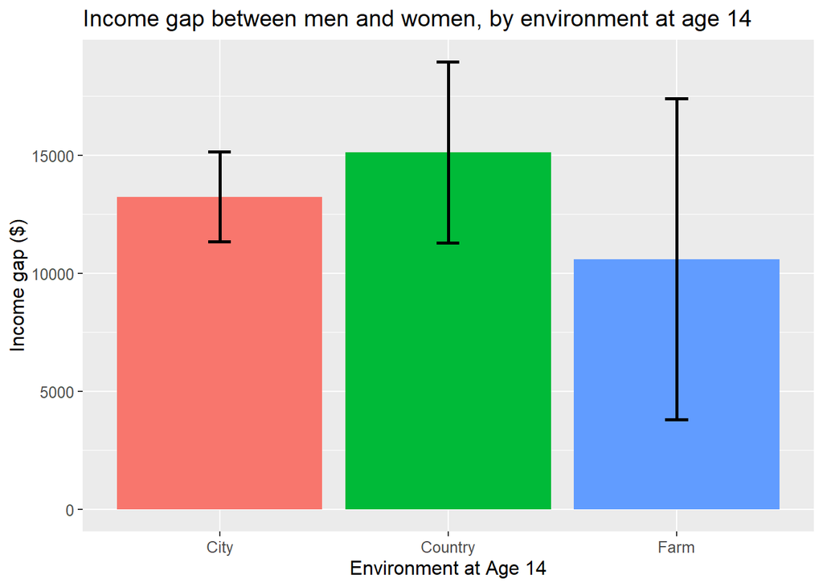

```
## # A tibble: 10 x 5
##    religion       income.gap  upper  lower is.significant
##    <fct>               <dbl>  <dbl>  <dbl>          <dbl>
##  1 No religion          847. -6687.  8380.              0
##  2 Protestant         16305.  8831. 23780.              1
##  3 Baptist             7451.  4769. 10133.              1
##  4 Episcopalian       14673.  -154. 29500.              0
##  5 Lutheran           13397.  5469. 21324.              1
##  6 Methodist          18026. 11596. 24455.              1
##  7 Presbyterian       20849.  8853. 32845.              1
##  8 Roman Catholic     17108. 14204. 20012.              1
##  9 Jewish             41127. 16183. 66071.              1
## 10 Other              16364. 11000. 21728.              1
```

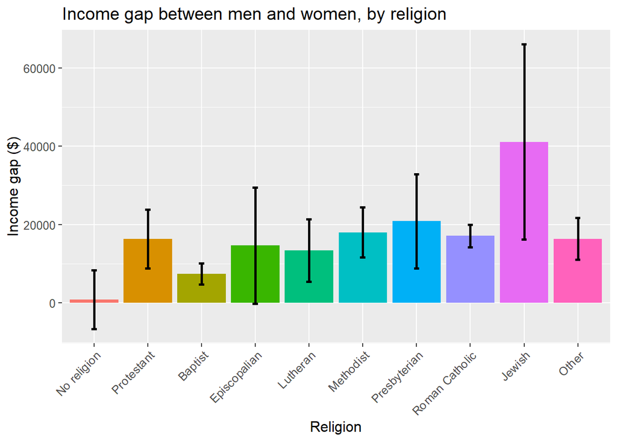

```
## # A tibble: 3 x 5
##   christian      income.gap  upper  lower is.significant
##   <fct>               <dbl>  <dbl>  <dbl>          <dbl>
## 1 Not Christian      12486.  8082. 16889.              1
## 2 Christian          11164.  8911. 13418.              1
## 3 Roman Catholic     17108. 14204. 20012.              1
```

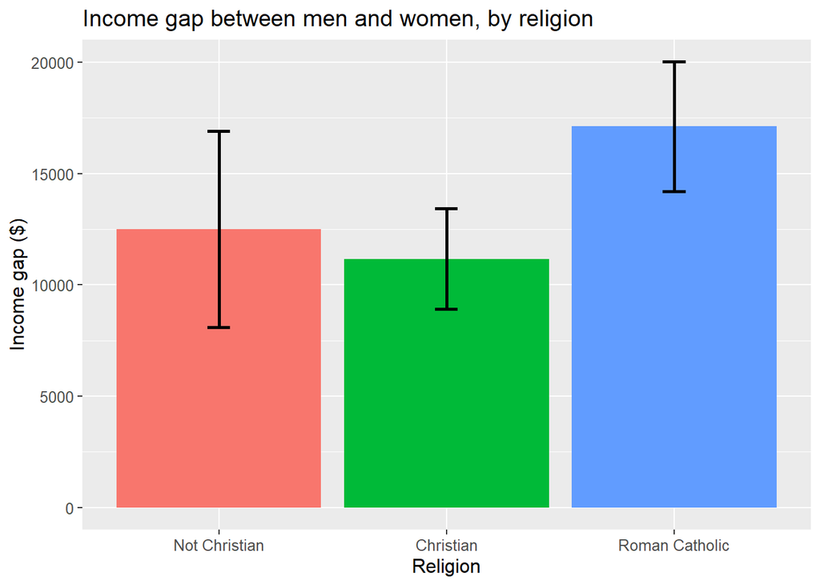

```
## # A tibble: 2 x 5
##   police.frisk income.gap  upper  lower is.significant
##   <fct>             <dbl>  <dbl>  <dbl>          <dbl>
## 1 Not Frisked      14785. 12854. 16716.              1
## 2 Frisked          10797.  6388. 15207.              1
```

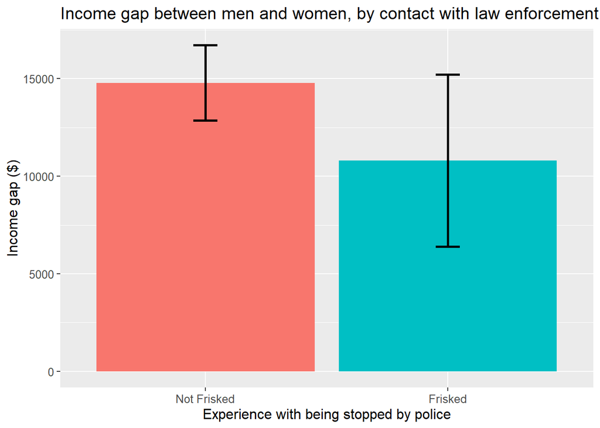

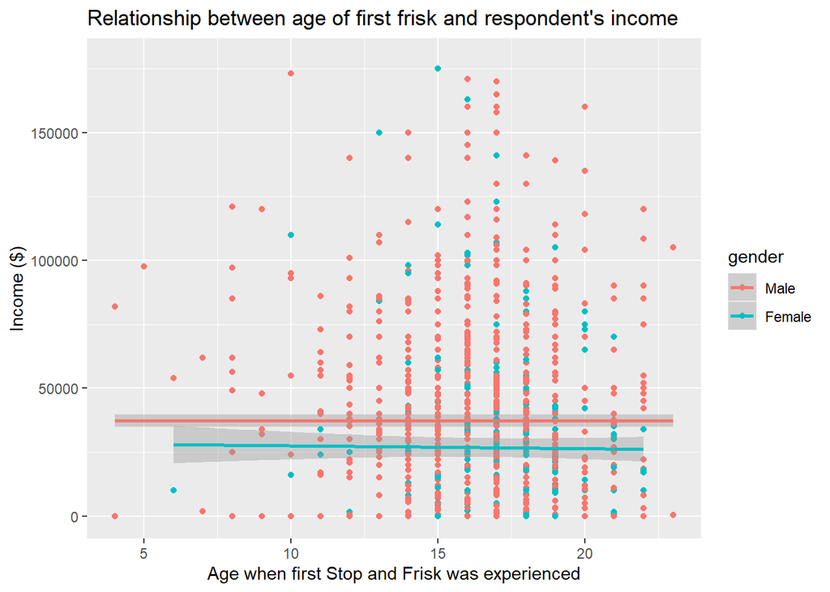

**(b)** Geographical

```
## # A tibble: 4 x 5
##   us.region     income.gap  upper  lower is.significant
##   <fct>              <dbl>  <dbl>  <dbl>          <dbl>
## 1 South             11850.  9325. 14374.              1
## 2 Northeast         13082.  8561. 17604.              1
## 3 North Central     14838. 11490. 18186.              1
## 4 West              14181. 10383. 17979.              1
```

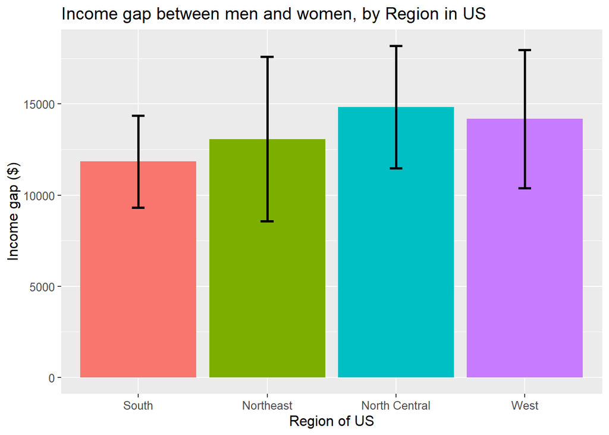

```
## # A tibble: 3 x 5
##   urban.residence income.gap  upper  lower is.significant
##   <fct>                <dbl>  <dbl>  <dbl>          <dbl>
## 1 Urban               13107. 11193. 15022.              1
## 2 Rural               14031. 10597. 17465.              1
## 3 Unknown             11494.   180. 22808.              1
```

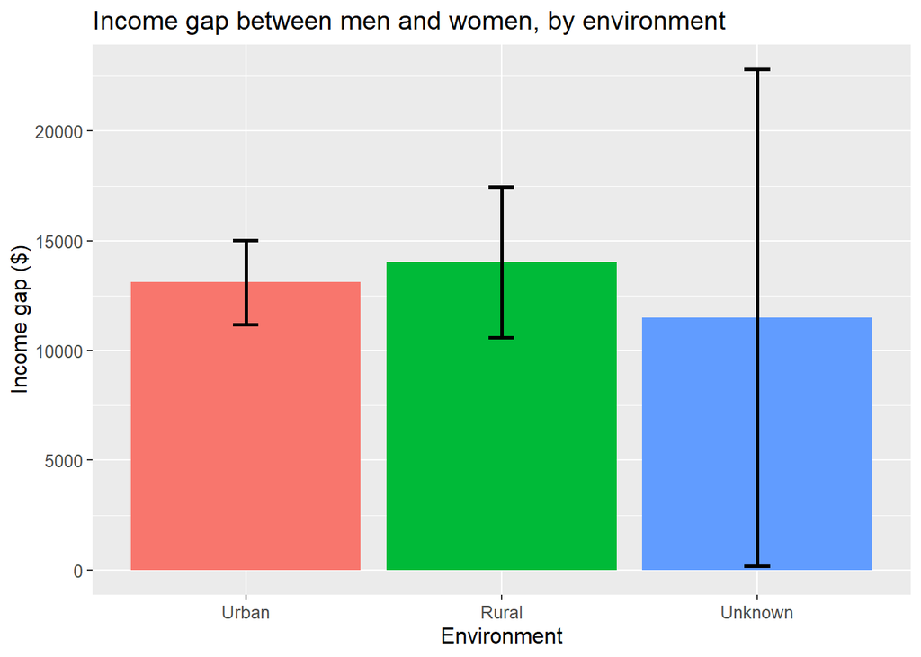

**(c)** Ethnicity and social status

```
## # A tibble: 3 x 5
##   race     income.gap  upper  lower is.significant
##   <fct>         <dbl>  <dbl>  <dbl>          <dbl>
## 1 Other        19559. 17066. 22052.              1
## 2 Hispanic     11125.  7596. 14654.              1
## 3 Black         5403.  2842.  7963.              1
```

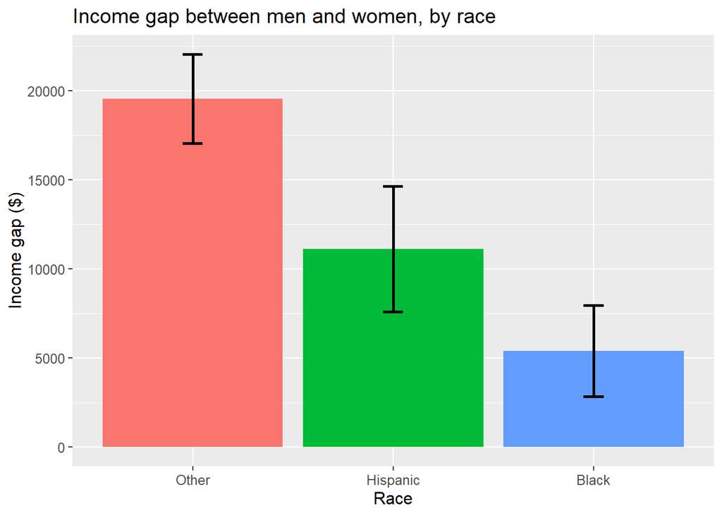

```
## # A tibble: 2 x 5
##   poverty1979    income.gap  upper  lower is.significant
##   <fct>               <dbl>  <dbl>  <dbl>          <dbl>
## 1 Not in Poverty     14897. 12736. 17059.              1
## 2 Poverty             7284.  4170. 10397.              1
```

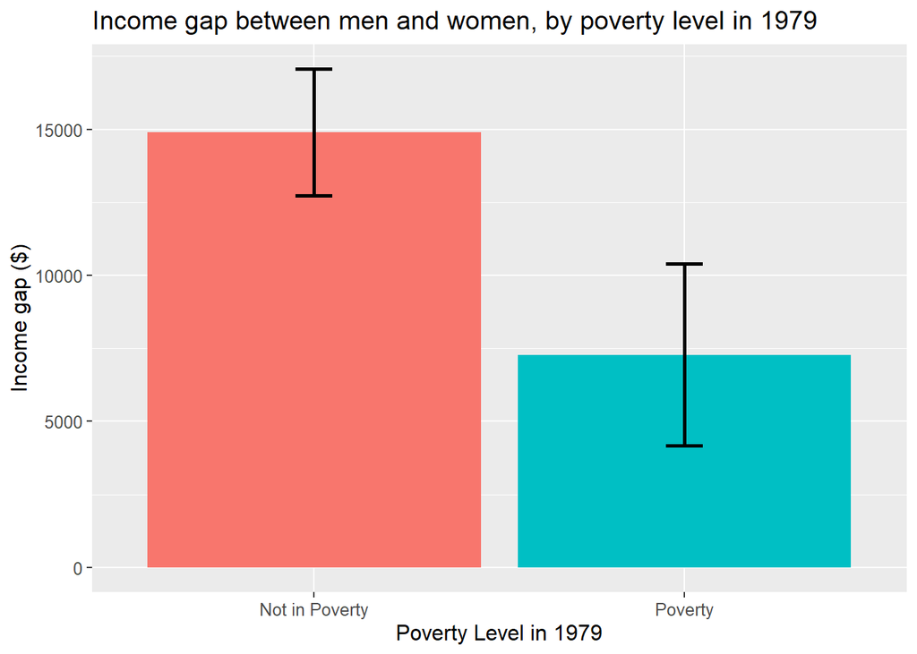

```
## # A tibble: 2 x 5
##   poverty1990    income.gap  upper  lower is.significant
##   <fct>               <dbl>  <dbl>  <dbl>          <dbl>
## 1 Not in Poverty     15226. 13192. 17261.              1
## 2 Poverty             4041.   712.  7370.              1
```

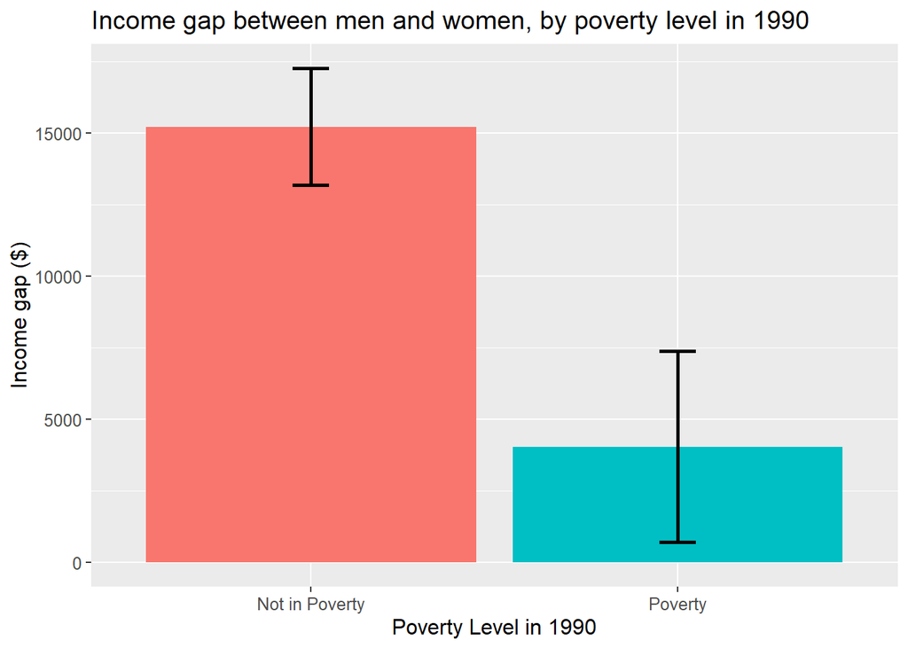

```
## # A tibble: 2 x 5
##   poverty2000    income.gap  upper  lower is.significant
##   <fct>               <dbl>  <dbl>  <dbl>          <dbl>
## 1 Not in Poverty     15089. 13010. 17169.              1
## 2 Poverty             1253. -1355.  3862.              0
```

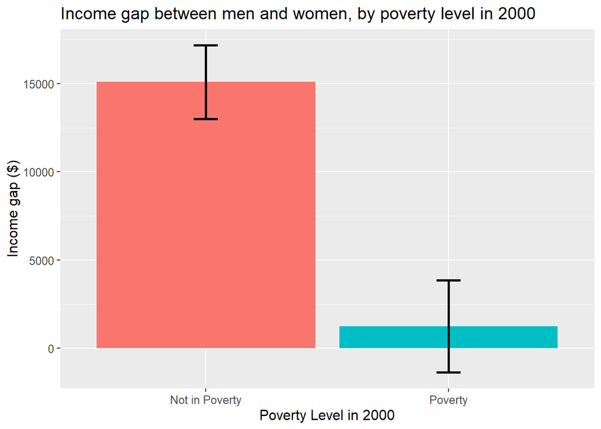

**(d)** Marriage and Family Planning

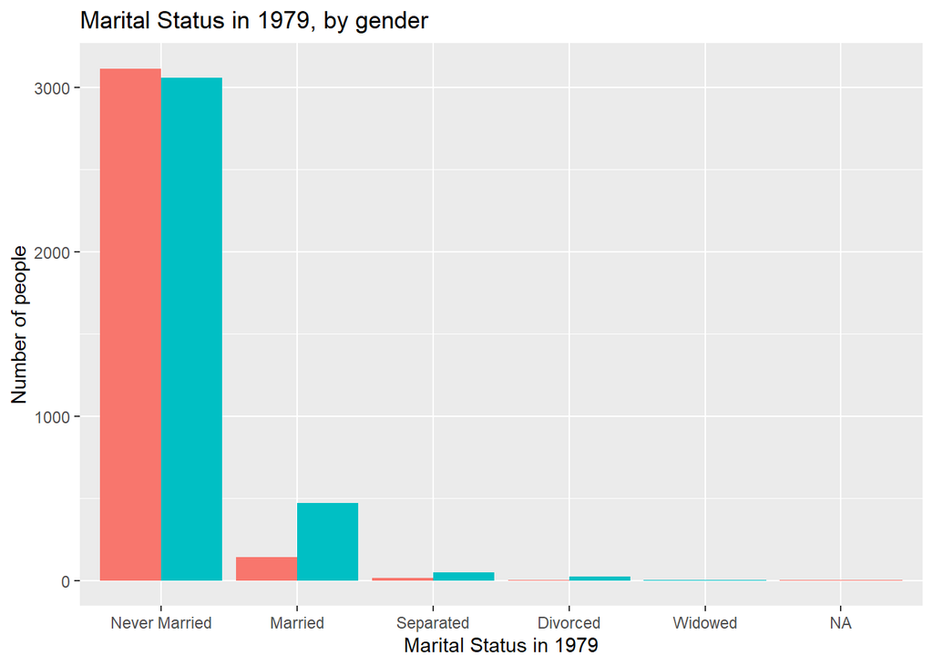

Most respondents were too young to be married in 1979. There were not enough data points in categories other than never married to get a meaningful data visualization of the income gap. The same problem applies to family size in 1979, in 2000 and 2012. There are not enough data at each level to see the difference in income between men and women, even when we treat family size and number of children as categorical variables.

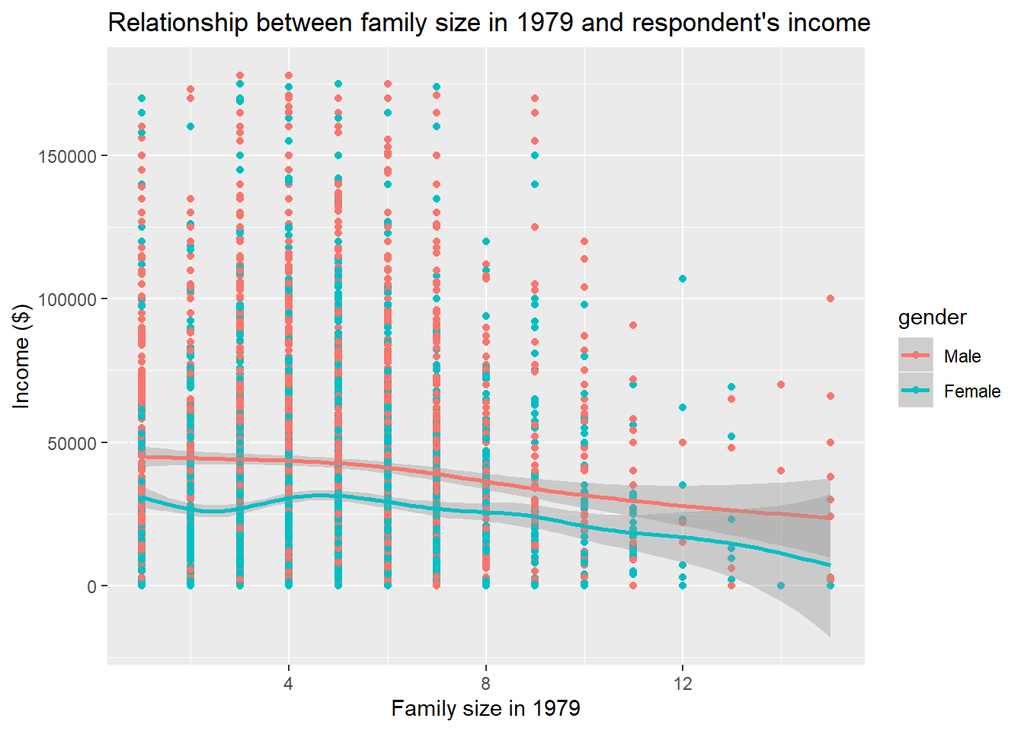

There are not enough observations to put a smooth line on adopted and step children graph.

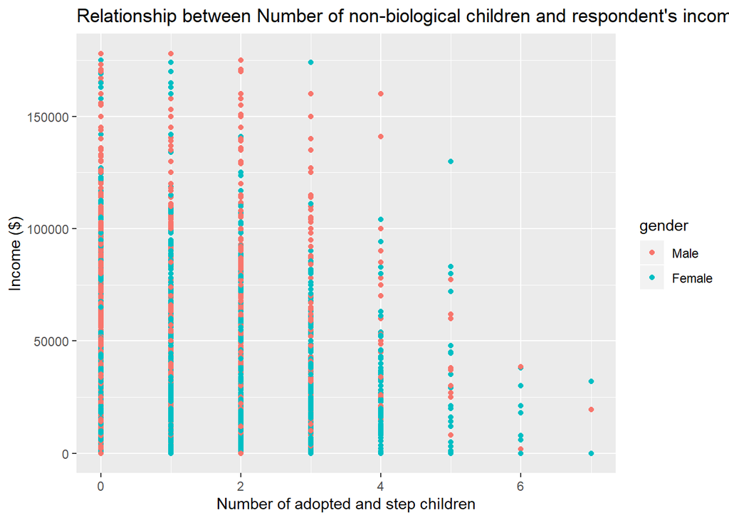

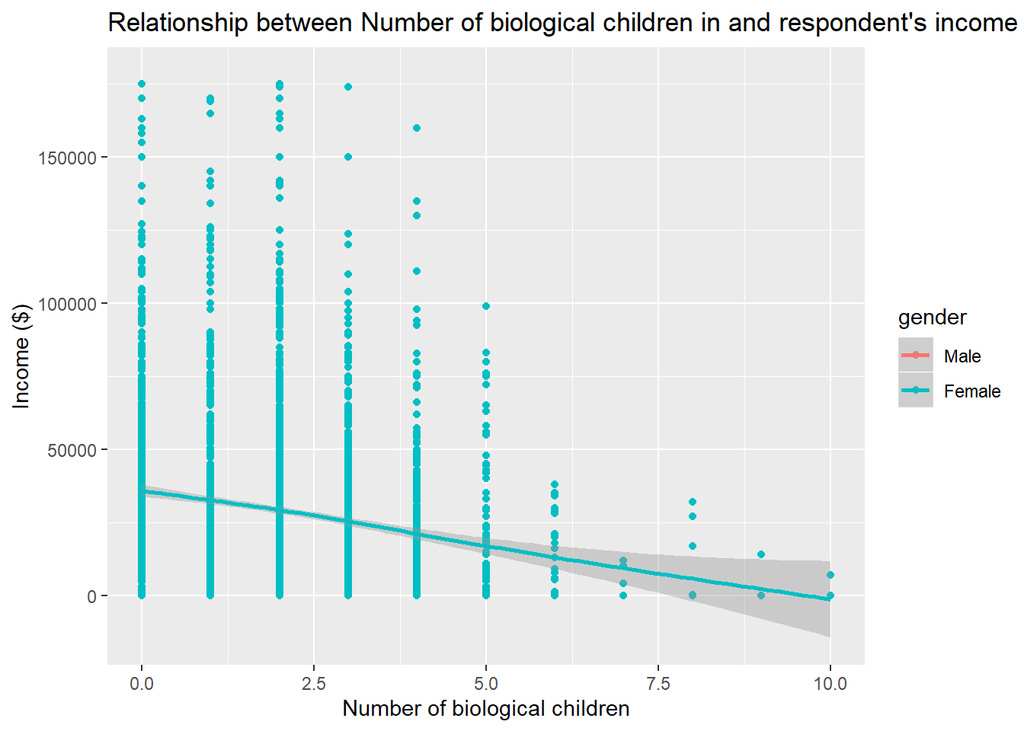

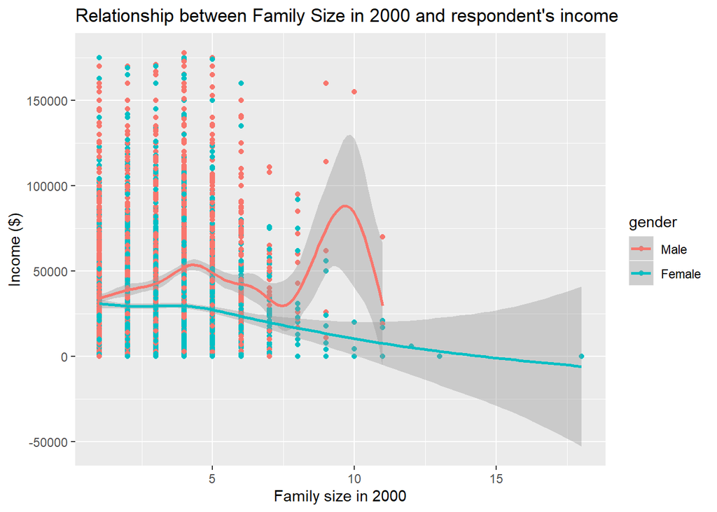

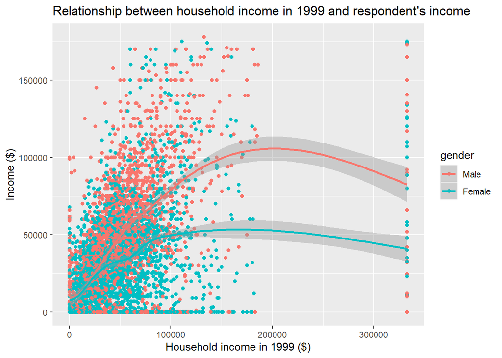

```
## # A tibble: 5 x 5
##   marital.status2000 income.gap   upper  lower is.significant
##   <fct>                   <dbl>   <dbl>  <dbl>          <dbl>
## 1 Never Married          -1823.  -5315.  1669.              0
## 2 Married                23195.  20904. 25485.              1
## 3 Separated               8360.   2055. 14664.              1
## 4 Divorced                4538.    354.  8723.              1
## 5 Widowed                 7650. -10473. 25772.              0
```

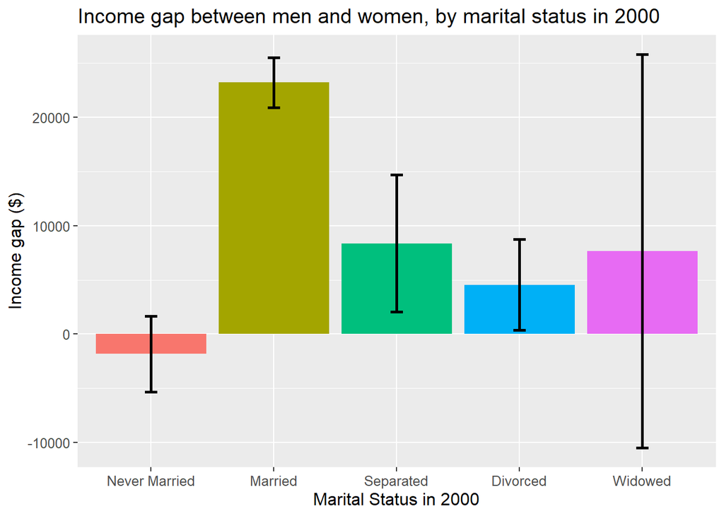

```
## # A tibble: 3 x 5
##   maritalc.status2000     income.gap  upper  lower is.significant
##   <fct>                        <dbl>  <dbl>  <dbl>          <dbl>
## 1 Never Married               -1823. -5315.  1669.              0
## 2 Married, Spouse Present     23713. 21383. 26043.              1
## 3 Other                        6248.  2963.  9533.              1
```

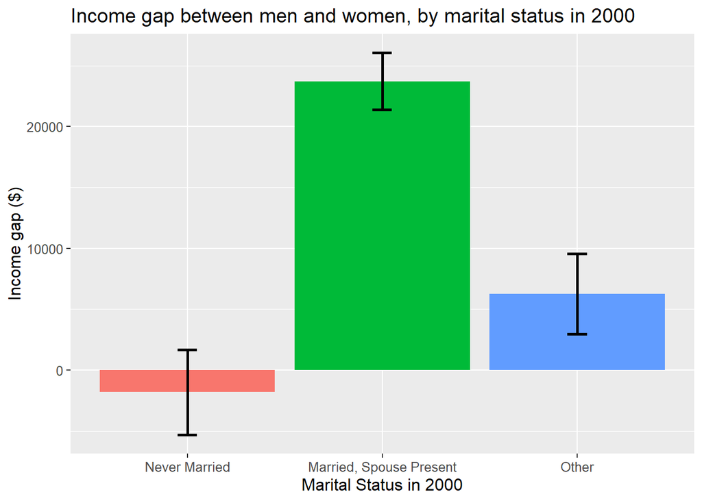

```
## # A tibble: 15 x 5
##    months.marryto1stkid income.gap    upper  lower is.significant
##    <fct>                     <dbl>    <dbl>  <dbl>          <dbl>
##  1 Same month                3074. -10732.  16879.              0
##  2 Within a year            17200.  13662.  20738.              1
##  3 2 years                  21370.  16739.  26001.              1
##  4 3 years                  22786.  17077.  28496.              1
##  5 4 years                  17770.  10738.  24802.              1
##  6 5 years                  20059.  11913.  28206.              1
##  7 6 years                  19412.  10322.  28502.              1
##  8 7 years                  23433.  12475.  34392.              1
##  9 8 years                  19099.   8792.  29406.              1
## 10 9 years                  20142.   7636.  32647.              1
## 11 11 years                 35206.  20102.  50310.              1
## 12 12 years                 16335.    -75.9 32746.              0
## 13 More than 12 years       12194.   4545.  19843.              1
## 14 Never married            -2208.  -6189.   1773.              0
## 15 No children               -601.  -4508.   3306.              0
```

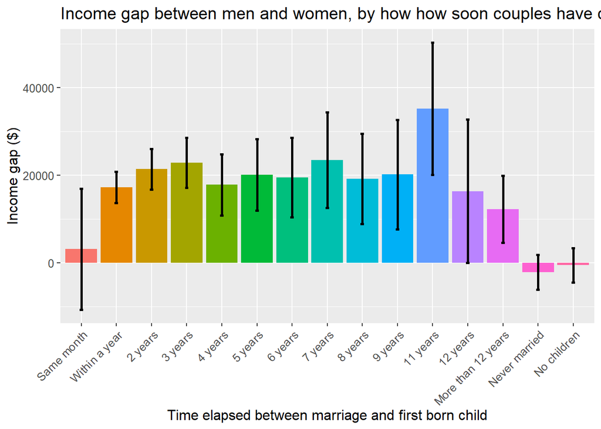

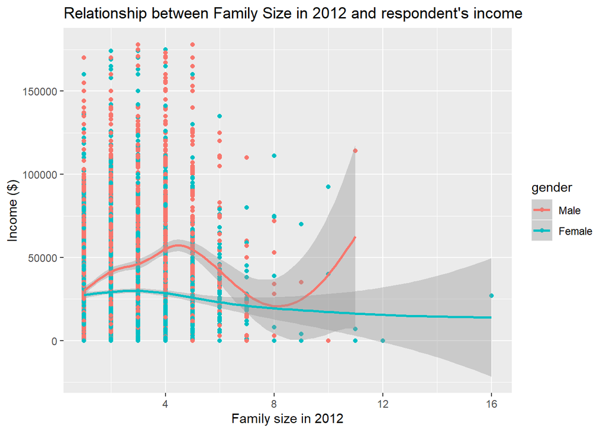

**(e)** Spouse

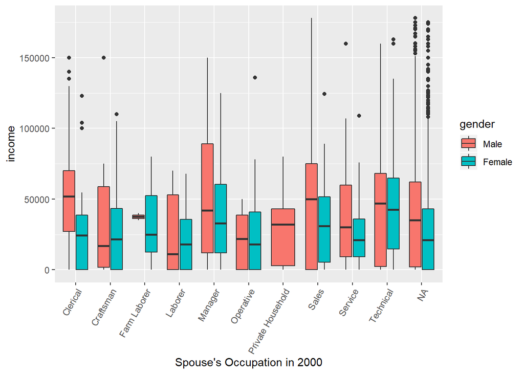

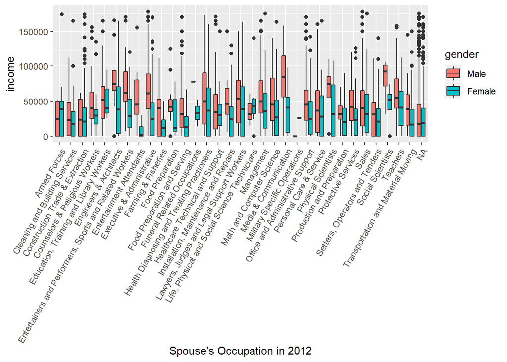

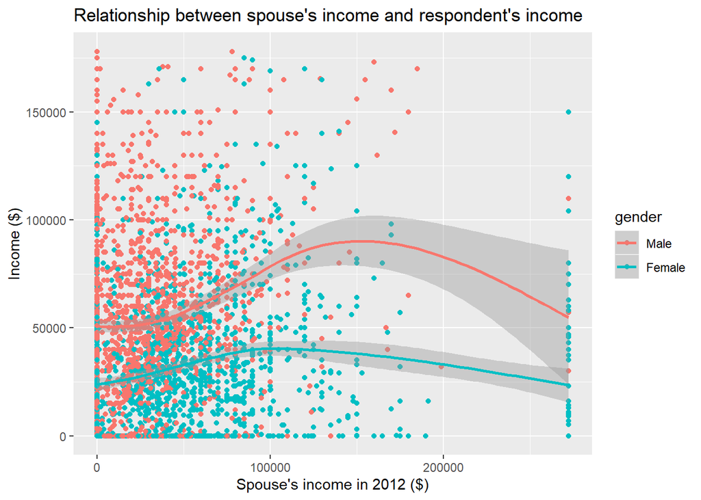

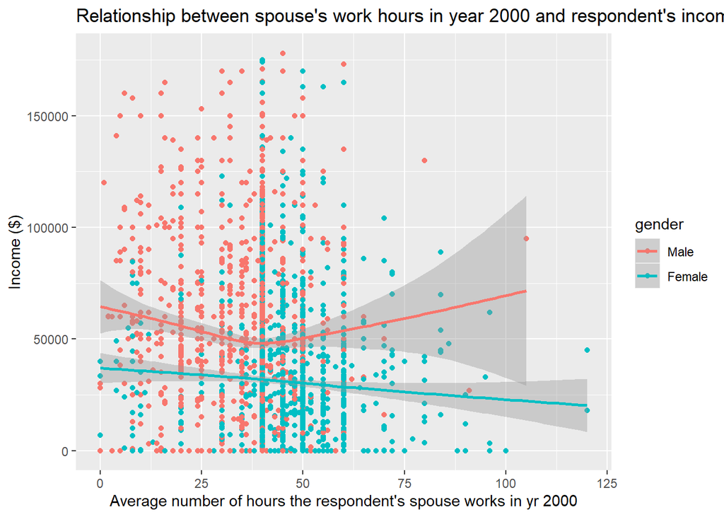

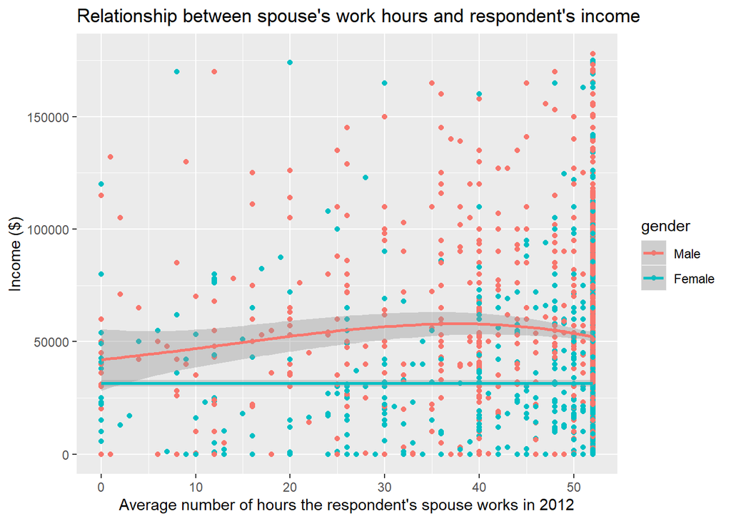